# Elegant and explanatory vulcano plots in R ggplot2

Tomasz Stępkowski

2020-05-16

## Data preparation

### Introduction

To prepare the vulcano plot like this:

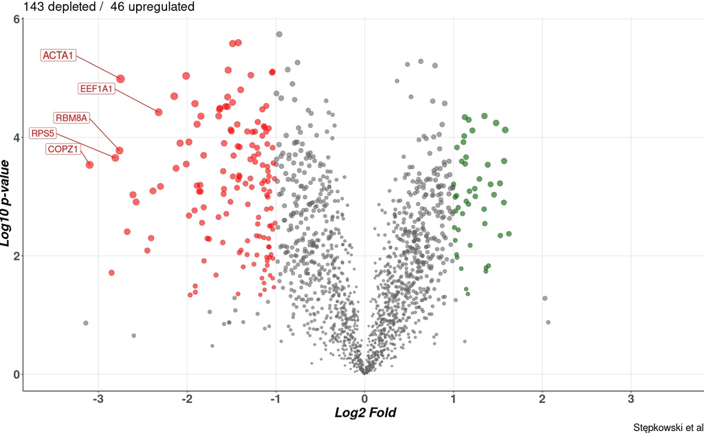

which is a special type of a scatter plot we need a dataframe type of data with at least two variables inside - Log2 fold change and -log10 p-value for reads of particular genes/proteins. For additional labeling of points we will need a gene/protein name variable. Too assign categorical variables to points we will need a column(variable) of data type - factor. If a file imported from excel contains a character string variable with categorical data we will need to change it to factor data type with as.factor() function. To analyze the structure of dataframe showing which datatypes are present inside the dataframe we use function str() from base or glimpse() from the “dplyr” library. The data type of a particular object can be checked by class() function. To install a particular library use install.packages(“library_name”) command. To downlaoad the functions availible in an installed library use library(“name”) command. For every function a help page is availible - just type ?function_name() in the console and the help page will appaer. For efficient processing in R data should be in a tidy format which is understood as a dataframe(table) in which every row is an observation and each column is a variable.

### Importing raw dataset

The data can be imported from excel with the function read_excel() availible in library(readxl). Similar functions exist for importing data from csv and tab deligned textfiles. THe # sign eneables commenting the code - everything after would not be executed…

```r
# The file Table2.xls is an example processed data from highthrouput biological experiment. The name was changed to Pilot_TMT_RAW. The file contains log2 fold changes and adjusted p- values for the comparison A vs. control and B vs. control
# Import full DataSet from Excel

library(readxl)
Pilot_TMT_RAW <- read_excel("Pilot_TMT_RAW.xlsx")
```